# Chapter 7 Lab 2 - K-Nearest Neighbor (KNN)

# Goal

In this lab, we will try to predict players’ skill level, i.e., column `SkillLevel`. In the data set, a player’s skill level is represented as a number between 0 and 3, with 0 being novice level and 3 expert. Intuitively, how skillful a player is in the game should be reflected through their in-game performance, such as number of kills and deaths.

We are going to use `KNN` model in this lab, which reflects the hypothesis: If players have similar in-game performance, they should have similar skill level. Is this true? We’ll see.

```r
# preparation: import libraries to be used.
options(repos = c(CRAN = "http://cran.rstudio.com"))
install.packages("caret", dependencies = TRUE)
library("caret")
```

# Step 1: Load the data set

Similar to Lab 7.1, we first load the data set into a dataframe, and examine it below.

```r
# we are assuming the data file is in the current directory. If not, you may want to set the current directory to where the data file is or adjust the path in the read.csv line below.

# read the CSV file
DotaData <- read.csv("DoTalicious_cleaned1000players.csv", fileEncoding="UTF-8-BOM")
summary(DotaData)
```

```
##     PlayerID       GamesPlayed         GamesWon         GamesLeft
##  Min.   :   0.0   Min.   :   0.00   Min.   :   0.00   Min.   : 0.000
##  1st Qu.: 242.8   1st Qu.:   3.00   1st Qu.:   1.00   1st Qu.: 0.000
##  Median : 499.5   Median :  15.00   Median :   7.00   Median : 0.000
##  Mean   : 497.7   Mean   :  92.24   Mean   :  50.31   Mean   : 1.649
##  3rd Qu.: 750.2   3rd Qu.:  90.00   3rd Qu.:  47.25   3rd Qu.: 2.000
##  Max.   :1000.0   Max.   :3156.00   Max.   :1764.00   Max.   :40.000
##     Ditches            Points        SkillLevel            Kills
##  Min.   : 0.0000   Min.   : 626.8   Length:868         Min.   :    0.0
##  1st Qu.: 0.0000   1st Qu.: 962.1   Class :character   1st Qu.:   11.0
##  Median : 0.0000   Median : 996.7   Mode  :character   Median :   74.0
##  Mean   : 0.7108   Mean   :1014.8                      Mean   :  608.0
##  3rd Qu.: 1.0000   3rd Qu.:1046.7                      3rd Qu.:  512.8
##  Max.   :18.0000   Max.   :2010.2                      Max.   :23742.0
##   KillsPerMin         Deaths           Assists         CreepsKilled
##  Min.   :0.0000   Min.   :    0.0   Min.   :    0.0   Min.   :     0.0
##  1st Qu.:0.0900   1st Qu.:   17.0   1st Qu.:   18.0   1st Qu.:   159.5
##  Median :0.1300   Median :   92.5   Median :  124.0   Median :   979.0
##  Mean   :0.1316   Mean   :  544.5   Mean   :  950.7   Mean   :  7628.0
##  3rd Qu.:0.1700   3rd Qu.:  554.0   3rd Qu.:  863.5   3rd Qu.:  6723.0
##  Max.   :0.4200   Max.   :16988.0   Max.   :34390.0   Max.   :372360.0
##   CreepsDenied     NeutralsKilled    TowersDestroyed   RaxsDestroyed
##  Min.   :    0.0   Min.   :    0.0   Min.   :   0.00   Min.   :   0.00
##  1st Qu.:   12.0   1st Qu.:   16.0   1st Qu.:   1.00   1st Qu.:   0.00
##  Median :   76.0   Median :  145.5   Median :   7.00   Median :   3.00
##  Mean   :  676.9   Mean   : 1258.3   Mean   :  70.71   Mean   :  29.71
##  3rd Qu.:  540.8   3rd Qu.: 1126.8   3rd Qu.:  61.50   3rd Qu.:  26.00
##  Max.   :43910.0   Max.   :42900.0   Max.   :2601.00   Max.   :1141.00
##   TotalTime
##  Length:868
##  Class :character
##  Mode  :character
##
##
##
```

As a recap, we can observe that: 1. Most features take continuous quantitative values, except `PlayerID` and `SkillLevel` 2. `SkillLevel` has one missing value, namely " SkillLevelNull" 3. `TotalTime` was loaded as discrete values.

As such, `TotalTime` is going to be converted into quantitative, the row with `SkillLevel` equal to `SkillLevelNull` removed, and`PlayerID` excluded from our variable set.

```r
# convert TotalTime
DotaData$TotalTime <- as.numeric(DotaData$TotalTime)
# exclude the row with SillLevel = SkillLevelNull
DotaData$SkillLevel <- as.factor(DotaData$SkillLevel)
DotaData <- DotaData[!(DotaData$SkillLevel == " SkillLevelNull"),]

# use factor in place of as.factor to remove " SkillLevelNull" from the list of factors
DotaData$SkillLevel <- factor(DotaData$SkillLevel)

# exclude PlayerID
DotaData <- DotaData[-1]

DotaData = na.omit(DotaData)

summary(DotaData)
```

```
##   GamesPlayed         GamesWon         GamesLeft         Ditches
##  Min.   :   1.00   Min.   :   0.00   Min.   : 0.000   Min.   : 0.0000
##  1st Qu.:   3.00   1st Qu.:   1.00   1st Qu.: 0.000   1st Qu.: 0.0000
##  Median :  15.00   Median :   7.00   Median : 0.000   Median : 0.0000
##  Mean   :  92.35   Mean   :  50.39   Mean   : 1.649   Mean   : 0.7125
##  3rd Qu.:  89.75   3rd Qu.:  47.75   3rd Qu.: 2.000   3rd Qu.: 1.0000
##  Max.   :3156.00   Max.   :1764.00   Max.   :40.000   Max.   :18.0000
##      Points       SkillLevel     Kills          KillsPerMin
##  Min.   : 626.8   0:446      Min.   :    0.0   Min.   :0.0000
##  1st Qu.: 962.3   1:391      1st Qu.:   11.0   1st Qu.:0.0900
##  Median : 996.7   2: 17      Median :   74.0   Median :0.1300
##  Mean   :1015.0   3: 12      Mean   :  608.8   Mean   :0.1318
##  3rd Qu.:1047.2              3rd Qu.:  516.2   3rd Qu.:0.1700
##  Max.   :2010.2              Max.   :23742.0   Max.   :0.4200
##      Deaths            Assists         CreepsKilled       CreepsDenied
##  Min.   :    0.00   Min.   :    0.0   Min.   :     9.0   Min.   :    0.0
##  1st Qu.:   17.25   1st Qu.:   18.0   1st Qu.:   160.2   1st Qu.:   12.0
##  Median :   92.50   Median :  124.0   Median :   979.0   Median :   76.0
##  Mean   :  545.09   Mean   :  952.0   Mean   :  7637.0   Mean   :  678.0
##  3rd Qu.:  554.00   3rd Qu.:  866.5   3rd Qu.:  6690.8   3rd Qu.:  542.2
##  Max.   :16988.00   Max.   :34390.0   Max.   :372360.0   Max.   :43910.0
##  NeutralsKilled    TowersDestroyed   RaxsDestroyed       TotalTime
##  Min.   :    0.0   Min.   :   0.00   Min.   :   0.00   Min.   :   1349
##  1st Qu.:   16.0   1st Qu.:   1.00   1st Qu.:   0.00   1st Qu.:   6255
##  Median :  145.5   Median :   7.00   Median :   3.00   Median :  35070
##  Mean   : 1258.7   Mean   :  70.79   Mean   :  29.74   Mean   : 228343
##  3rd Qu.: 1118.5   3rd Qu.:  61.00   3rd Qu.:  26.00   3rd Qu.: 220815
##  Max.   :42900.0   Max.   :2601.00   Max.   :1141.00   Max.   :4294920
```

Further examining `SkillLevel` shows that the majority of players are novice (i.e., level 0 and 1).

```r
#look at the totals to see where the majority of the points lie in terms of skills sets
table(DotaData$SkillLevel)
```

```
##
##   0   1   2   3
## 446 391  17  12
```

# Step 2: Set up training and testing set and preprocess

Next, we are going to split the data into training and testing set.

```r
# setting the random seed: you can choose your own seed.
set.seed(101)

#Spliting data as training and test set. Using createDataPartition() function from caret
# as you can see we are taking 75% of the data to train and the rest to test.

indxTrain <- createDataPartition(y = DotaData$SkillLevel,p = 0.75,list = FALSE)
training <- DotaData[indxTrain,]
testing <- DotaData[-indxTrain,]
summary(training)
```

```
##   GamesPlayed         GamesWon         GamesLeft         Ditches
##  Min.   :   1.00   Min.   :   0.00   Min.   : 0.000   Min.   : 0.0000
##  1st Qu.:   3.00   1st Qu.:   1.00   1st Qu.: 0.000   1st Qu.: 0.0000
##  Median :  16.00   Median :   7.00   Median : 0.000   Median : 0.0000
##  Mean   :  92.07   Mean   :  50.69   Mean   : 1.639   Mean   : 0.6882
##  3rd Qu.:  90.00   3rd Qu.:  47.50   3rd Qu.: 2.000   3rd Qu.: 1.0000
##  Max.   :3156.00   Max.   :1764.00   Max.   :40.000   Max.   :15.0000
##      Points       SkillLevel     Kills          KillsPerMin
##  Min.   : 626.8   0:335      Min.   :    0.0   Min.   :0.0000
##  1st Qu.: 963.9   1:294      1st Qu.:   11.0   1st Qu.:0.0900
##  Median :1000.0   2: 13      Median :   74.0   Median :0.1300
##  Mean   :1016.0   3:  9      Mean   :  616.5   Mean   :0.1332
##  3rd Qu.:1044.7              3rd Qu.:  514.5   3rd Qu.:0.1700
##  Max.   :2010.2              Max.   :23742.0   Max.   :0.4200
##      Deaths           Assists         CreepsKilled     CreepsDenied
##  Min.   :    0.0   Min.   :    0.0   Min.   :     9   Min.   :    0.0
##  1st Qu.:   16.0   1st Qu.:   18.0   1st Qu.:   156   1st Qu.:   12.0
##  Median :  100.0   Median :  130.0   Median :   991   Median :   79.0
##  Mean   :  539.6   Mean   :  959.8   Mean   :  7558   Mean   :  674.8
##  3rd Qu.:  548.5   3rd Qu.:  882.0   3rd Qu.:  6528   3rd Qu.:  541.5
##  Max.   :16988.0   Max.   :34390.0   Max.   :372360   Max.   :43910.0
##  NeutralsKilled  TowersDestroyed   RaxsDestroyed       TotalTime
##  Min.   :    0   Min.   :   0.00   Min.   :   0.00   Min.   :   1349
##  1st Qu.:   15   1st Qu.:   1.00   1st Qu.:   0.00   1st Qu.:   5970
##  Median :  156   Median :   7.00   Median :   3.00   Median :  36540
##  Mean   : 1264   Mean   :  70.42   Mean   :  29.71   Mean   : 225830
##  3rd Qu.: 1073   3rd Qu.:  60.00   3rd Qu.:  25.00   3rd Qu.: 227100
##  Max.   :42900   Max.   :2601.00   Max.   :1141.00   Max.   :4294920
```

```r
summary(testing)
```

```
##   GamesPlayed         GamesWon        GamesLeft         Ditches
##  Min.   :   1.00   Min.   :  0.00   Min.   : 0.000   Min.   : 0.000
##  1st Qu.:   3.00   1st Qu.:  1.00   1st Qu.: 0.000   1st Qu.: 0.000
##  Median :  13.00   Median :  6.00   Median : 0.000   Median : 0.000
##  Mean   :  93.19   Mean   : 49.46   Mean   : 1.679   Mean   : 0.786
##  3rd Qu.:  85.00   3rd Qu.: 49.00   3rd Qu.: 2.000   3rd Qu.: 1.000
##  Max.   :1362.00   Max.   :816.00   Max.   :18.000   Max.   :18.000
##      Points       SkillLevel     Kills          KillsPerMin
##  Min.   : 691.3   0:111      Min.   :    0.0   Min.   :0.0000
##  1st Qu.: 954.4   1: 97      1st Qu.:   12.5   1st Qu.:0.0800
##  Median : 994.3   2:  4      Median :   69.0   Median :0.1200
##  Mean   :1011.7   3:  3      Mean   :  585.6   Mean   :0.1276
##  3rd Qu.:1054.5              3rd Qu.:  529.5   3rd Qu.:0.1700
##  Max.   :1592.6              Max.   :11457.0   Max.   :0.3700
##      Deaths          Assists         CreepsKilled     CreepsDenied
##  Min.   :   2.0   Min.   :    0.0   Min.   :    10   Min.   :    0.0
##  1st Qu.:  21.5   1st Qu.:   18.5   1st Qu.:   183   1st Qu.:   12.0
##  Median :  78.0   Median :  100.0   Median :   914   Median :   69.0
##  Mean   : 561.6   Mean   :  928.7   Mean   :  7875   Mean   :  687.9
##  3rd Qu.: 569.0   3rd Qu.:  783.0   3rd Qu.:  6884   3rd Qu.:  538.0
##  Max.   :9322.0   Max.   :14645.0   Max.   :142043   Max.   :13030.0
##  NeutralsKilled  TowersDestroyed  RaxsDestroyed      TotalTime
##  Min.   :    0   Min.   :   0.0   Min.   :  0.00   Min.   :   1354
##  1st Qu.:   19   1st Qu.:   1.0   1st Qu.:  0.00   1st Qu.:   7080
##  Median :  116   Median :   7.0   Median :  3.00   Median :  29820
##  Mean   : 1242   Mean   :  71.9   Mean   : 29.85   Mean   : 235952
##  3rd Qu.: 1218   3rd Qu.:  64.0   3rd Qu.: 31.00   3rd Qu.: 215430
##  Max.   :21770   Max.   :1501.0   Max.   :662.00   Max.   :3557400
```

Notes:  
* `set.seed()` is the function that allows us to set a random seed for all subsequent routines that use random sampling * `createDataPartition` randomly selects a set of row indices for training set. We set the ratio for training data to be 75% using `p=0.75`

## Preprocessing

We are going to standardize the independent attributes of the training data. The question is: Should we *standardize* or *normalize* the features? As discussed in Chapter 2, while both *standardization* and *normalization* are used for scaling data features, each has their own pros and cons (please refer to Chapter 2 for more information). Standardization is more robust against outliers, so in this case, since our data appear to have outliers, standardization will be more suitable than normalization.

With `caret`, standardization can be achieved by apply `center` (i.e., subtract by the mean) and `scaling` (i.e., divided by the standard deviation) in sequence.

```r
preProcValues <- preProcess(x = training,method = c("center", "scale"))
preProcValues
```

```
## Created from 651 samples and 16 variables
##
## Pre-processing:
##   - centered (15)
##   - ignored (1)
##   - scaled (15)
```

`preProcValues` captures the preprocessing model extracted from the input data, i.e., `training`. Specifically, `preProcValues` contains information about the procedures to be applied, i.e., centering and scaling, as well as relevant values such as the means and standard deviations of numeric columns. Note that factor columns, e.g., *SkillLevel*, are ignored.

Next, we will apply this model on both the training and test data.

```r
# transform the training data using preProcValues
trainTransformed <- predict(preProcValues, training)
summary(trainTransformed)
```

```
##   GamesPlayed           GamesWon         GamesLeft          Ditches
##  Min.   :-0.433199   Min.   :-0.4239   Min.   :-0.5009   Min.   :-0.3941
##  1st Qu.:-0.423686   1st Qu.:-0.4155   1st Qu.:-0.5009   1st Qu.:-0.3941
##  Median :-0.361846   Median :-0.3654   Median :-0.5009   Median :-0.3941
##  Mean   : 0.000000   Mean   : 0.0000   Mean   : 0.0000   Mean   : 0.0000
##  3rd Qu.:-0.009835   3rd Qu.:-0.0267   3rd Qu.: 0.1103   3rd Qu.: 0.1786
##  Max.   :14.574822   Max.   :14.3273   Max.   :11.7246   Max.   : 8.1966
##      Points        SkillLevel     Kills           KillsPerMin
##  Min.   :-3.2331   0:335      Min.   :-0.39397   Min.   :-1.98065
##  1st Qu.:-0.4332   1:294      1st Qu.:-0.38694   1st Qu.:-0.64248
##  Median :-0.1331   2: 13      Median :-0.34668   Median :-0.04773
##  Mean   : 0.0000   3:  9      Mean   : 0.00000   Mean   : 0.00000
##  3rd Qu.: 0.2382              3rd Qu.:-0.06518   3rd Qu.: 0.54701
##  Max.   : 8.2593              Max.   :14.77854   Max.   : 4.26415
##      Deaths             Assists          CreepsKilled       CreepsDenied
##  Min.   :-0.445698   Min.   :-0.41281   Min.   :-0.36915   Min.   :-0.3154
##  1st Qu.:-0.432483   1st Qu.:-0.40507   1st Qu.:-0.36196   1st Qu.:-0.3098
##  Median :-0.363105   Median :-0.35690   Median :-0.32113   Median :-0.2785
##  Mean   : 0.000000   Mean   : 0.00000   Mean   : 0.00000   Mean   : 0.0000
##  3rd Qu.: 0.007324   3rd Qu.:-0.03345   3rd Qu.:-0.05036   3rd Qu.:-0.0623
##  Max.   :13.585174   Max.   :14.37906   Max.   :17.83787   Max.   :20.2111
##  NeutralsKilled     TowersDestroyed   RaxsDestroyed        TotalTime
##  Min.   :-0.41722   Min.   :-0.3952   Min.   :-0.39091   Min.   :-0.47895
##  1st Qu.:-0.41227   1st Qu.:-0.3896   1st Qu.:-0.39091   1st Qu.:-0.46909
##  Median :-0.36574   Median :-0.3559   Median :-0.35144   Median :-0.40386
##  Mean   : 0.00000   Mean   : 0.0000   Mean   : 0.00000   Mean   : 0.00000
##  3rd Qu.:-0.06312   3rd Qu.:-0.0585   3rd Qu.:-0.06195   3rd Qu.: 0.00271
##  Max.   :13.74019   Max.   :14.2021   Max.   :14.62291   Max.   : 8.68173
```

```r
# Apply the same processing, using preprocessing information from the training data, onto the test data
testTransformed <- predict(preProcValues, testing)
summary(testTransformed)
```

```
##   GamesPlayed           GamesWon          GamesLeft           Ditches
##  Min.   :-0.433199   Min.   :-0.42391   Min.   :-0.50095   Min.   :-0.39413
##  1st Qu.:-0.423686   1st Qu.:-0.41555   1st Qu.:-0.50095   1st Qu.:-0.39413
##  Median :-0.376117   Median :-0.37374   Median :-0.50095   Median :-0.39413
##  Mean   : 0.005343   Mean   :-0.01034   Mean   : 0.01224   Mean   : 0.05605
##  3rd Qu.:-0.033620   3rd Qu.:-0.01416   3rd Qu.: 0.11033   3rd Qu.: 0.17859
##  Max.   : 6.040942   Max.   : 6.39980   Max.   : 5.00056   Max.   : 9.91473
##      Points         SkillLevel     Kills           KillsPerMin
##  Min.   :-2.69741   0:111      Min.   :-0.39397   Min.   :-1.9806
##  1st Qu.:-0.51178   1: 97      1st Qu.:-0.38599   1st Qu.:-0.7912
##  Median :-0.18043   2:  4      Median :-0.34988   Median :-0.1964
##  Mean   :-0.03581   3:  3      Mean   :-0.01971   Mean   :-0.0837
##  3rd Qu.: 0.32003              3rd Qu.:-0.05559   3rd Qu.: 0.5470
##  Max.   : 4.78973              Max.   : 6.92771   Max.   : 3.5207
##      Deaths            Assists          CreepsKilled       CreepsDenied
##  Min.   :-0.44405   Min.   :-0.41281   Min.   :-0.36910   Min.   :-0.315438
##  1st Qu.:-0.42794   1st Qu.:-0.40486   1st Qu.:-0.36064   1st Qu.:-0.309828
##  Median :-0.38128   Median :-0.36980   Median :-0.32489   Median :-0.283182
##  Mean   : 0.01814   Mean   :-0.01337   Mean   : 0.01547   Mean   : 0.006128
##  3rd Qu.: 0.02425   3rd Qu.:-0.07603   3rd Qu.:-0.03300   3rd Qu.:-0.063940
##  Max.   : 7.25361   Max.   : 5.88631   Max.   : 6.57595   Max.   : 5.775661
##  NeutralsKilled      TowersDestroyed     RaxsDestroyed         TotalTime
##  Min.   :-0.417217   Min.   :-0.395232   Min.   :-0.390914   Min.   :-0.47894
##  1st Qu.:-0.410947   1st Qu.:-0.389620   1st Qu.:-0.390914   1st Qu.:-0.46672
##  Median :-0.378936   Median :-0.355947   Median :-0.351439   Median :-0.41820
##  Mean   :-0.007367   Mean   : 0.008297   Mean   : 0.001882   Mean   : 0.02160
##  3rd Qu.:-0.015101   3rd Qu.:-0.036052   3rd Qu.: 0.016999   3rd Qu.:-0.02219
##  Max.   : 6.767090   Max.   : 8.028653   Max.   : 8.319999   Max.   : 7.10817
```

At this point, you may ask: Why didn’t we standardize the original data set first, then split into training and test sets? That would have saved us the hassle of the complicated preprocessing steps above (i.e., using `preProcValues`), right?

However, we would be **cheating** if we do so. When building a predictive model meant for predicting values unseen before, you are not supposed to know anything about the test set. So, preprocessing the original data set altogether means that you are using test set’s data at training phase, which is prohibited. You can also extrapolate what that means to the data when you do this and you will see how this can impact the data, and thus is problematic.

# Step 3: Apply the KNN model

Now, we are applying the KNN model on the data.

```r
set.seed(101)
ctrl <- trainControl(method="repeatedcv", number = 10, repeats = 3)
knn_output <- train(SkillLevel ~ ., data = trainTransformed, method = "knn", trControl = ctrl, tuneLength = 20)

#Output of the training
knn_output
```

```
## k-Nearest Neighbors
##
## 651 samples
##  15 predictor
##   4 classes: '0', '1', '2', '3'
##
## No pre-processing
## Resampling: Cross-Validated (10 fold, repeated 3 times)
## Summary of sample sizes: 586, 586, 587, 586, 586, 586, ...
## Resampling results across tuning parameters:
##
##   k   Accuracy   Kappa
##    5  0.8551195  0.7190118
##    7  0.8510477  0.7101520
##    9  0.8495170  0.7065647
##   11  0.8439224  0.6945252
##   13  0.8439224  0.6943152
##   15  0.8403324  0.6870252
##   17  0.8362449  0.6788235
##   19  0.8357323  0.6778363
##   21  0.8311084  0.6684761
##   23  0.8280388  0.6624096
##   25  0.8305959  0.6674644
##   27  0.8300748  0.6663623
##   29  0.8321261  0.6703857
##   31  0.8285286  0.6632087
##   33  0.8259484  0.6579751
##   35  0.8259562  0.6579540
##   37  0.8249306  0.6558229
##   39  0.8244175  0.6548177
##   41  0.8239047  0.6537893
##   43  0.8239047  0.6536973
##
## Accuracy was used to select the optimal model using the largest value.
## The final value used for the model was k = 5.
```

Some notes: * As we apply the `KNN` model, we have the option to pass in a parameter called *trainControl*. This optional parameter allows us to control the tuning process. In the code above, we set the tuning to use repeated cross validation (`repeatedcv`). `number` sets the number of folds, and `repeats` the number of separate cross-validations is run. * The `tuneLength` parameter defines the total number of hyperparameter combinations that will be evaluated. Since KNN only has one hyperparameter (i.e., `K`), `tuneLength` sets the number of K values to try. * The accuracy results shown are those of cross validation

More information on `trainControl`, and more generally the `caret` package can be found in *Further Readings* in the chapter. In the above setup, we: * applied standardization to the training data, and * used repeated cross validation to tune the parameter `K`

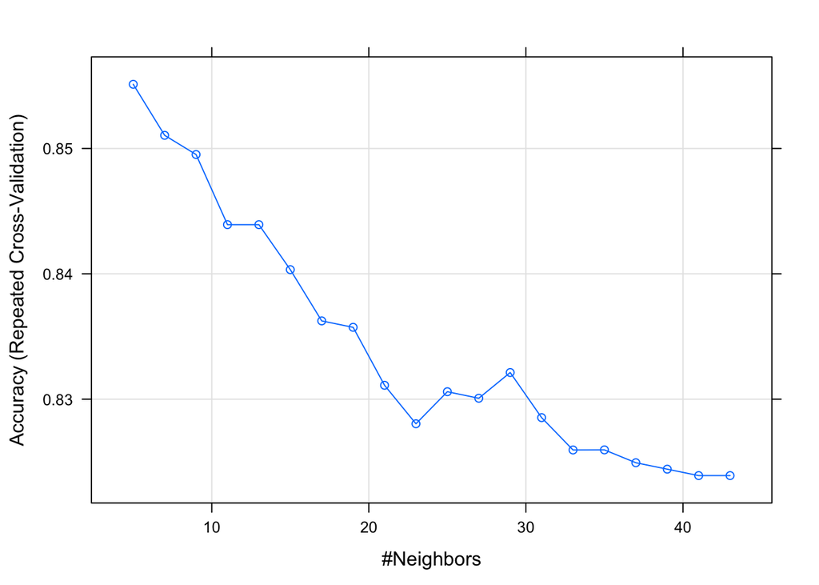

```r
plot(knn_output)
```

Use the trained KNN model to predict labels:

```r
knn_predict <- predict(knn_output,newdata = testTransformed )
#Get the confusion matrix to see accuracy value and other parameter values
confusionMatrix(knn_predict, testTransformed$SkillLevel )
```

```
## Confusion Matrix and Statistics
##
##           Reference
## Prediction   0   1   2   3
##          0 106  20   0   0
##          1   5  76   4   3
##          2   0   0   0   0
##          3   0   1   0   0
##
## Overall Statistics
##
##                Accuracy : 0.8465
##                  95% CI : (0.7913, 0.8919)
##     No Information Rate : 0.5163
##     P-Value [Acc > NIR] : < 2.2e-16
##
##                   Kappa : 0.7006
##
##  Mcnemar's Test P-Value : NA
##
## Statistics by Class:
##
##                      Class: 0 Class: 1 Class: 2 Class: 3
## Sensitivity            0.9550   0.7835   0.0000 0.000000
## Specificity            0.8077   0.8983   1.0000 0.995283
## Pos Pred Value         0.8413   0.8636      NaN 0.000000
## Neg Pred Value         0.9438   0.8346   0.9814 0.985981
## Prevalence             0.5163   0.4512   0.0186 0.013953
## Detection Rate         0.4930   0.3535   0.0000 0.000000
## Detection Prevalence   0.5860   0.4093   0.0000 0.004651
## Balanced Accuracy      0.8813   0.8409   0.5000 0.497642
```

The results here show confusion matrix, which will be discussed in more detail in Chapter 8. But for now it shows you how many labels were predicted correctly and how many were mislabeled and how they were mislabeled.

```r
dummy_model <- nullModel(y=trainTransformed$SkillLevel)
dummy_predict <- predict(dummy_model, newdata = testTransformed)
confusionMatrix(dummy_predict, testTransformed$SkillLevel )
```

```
## Confusion Matrix and Statistics
##
##           Reference
## Prediction   0   1   2   3
##          0 111  97   4   3
##          1   0   0   0   0
##          2   0   0   0   0
##          3   0   0   0   0
##
## Overall Statistics
##
##                Accuracy : 0.5163
##                  95% CI : (0.4473, 0.5848)
##     No Information Rate : 0.5163
##     P-Value [Acc > NIR] : 0.5275
##
##                   Kappa : 0
##
##  Mcnemar's Test P-Value : NA
##
## Statistics by Class:
##
##                      Class: 0 Class: 1 Class: 2 Class: 3
## Sensitivity            1.0000   0.0000   0.0000  0.00000
## Specificity            0.0000   1.0000   1.0000  1.00000
## Pos Pred Value         0.5163      NaN      NaN      NaN
## Neg Pred Value            NaN   0.5488   0.9814  0.98605
## Prevalence             0.5163   0.4512   0.0186  0.01395
## Detection Rate         0.5163   0.0000   0.0000  0.00000
## Detection Prevalence   1.0000   0.0000   0.0000  0.00000
## Balanced Accuracy      0.5000   0.5000   0.5000  0.50000
```

For classification problems, `nullModel` always returns the class with the highest frequency in the training data. That’s why all its predictions, as shown in the resultant confusion matrix, take value 0. The accuracy of this dummy model is 51.63%.

We can see that KNN performs much better than this dummy baseline.

# Conclusion

In this lab, we showed how to train `KNN` models for classification tasks, using the *caret* package. Other steps in the ML process such as preprocessing (e.g., standardizing the data) and hyperparameter tuning were also demonstrated.